# Final_Project

Fariba

2022-06-26

# 1 Introduction

The goal of this project is to determine the relationship between commuting to Wallonia communes as a dependent variable and life expectancy, age average, unemployment rate, percentage of non-Belgians, and total population in 2013.

First, collect all of the libraries that are required for this project.

```r
library(corrgram)
library(RColorBrewer)
library(MASS)
library(spatial)
library(splancs)
library(spatstat)
library(animation)
library(car)
library(yaml)
library(classInt)
library(dplyr)
library(GGally)
library(ggplot2)
library(GWmodel)
library(kableExtra)
library(leaflet)
library(lmtest)
library(lubridate)
library(maptools)
library(MASS)
library(openxlsx)
library(raster)
library(RColorBrewer)
library(rgdal)
library(rgeos)
library(sandwich)
library(sf)
library(sp)
library(spatial)
library(spatialreg)
library(spatstat)
library(spdep)
library(splancs)
library(tmap)
library(tmaptools)
```

## 1.1 Data Collection

the information obtained from the website(walstat.iweps.be).For this project, I use the commute among Wallonia’s communs as well as socioeconomic data such as life expectancy, average age, unemployment rate, and percentage of non-Belgians in 2013.

### 1.1.1 Total population in 2013

```r
#for all of the variable retrieved the common "Code_INS" for merging function

Wa_pop1<-read.csv("Data/Population.csv",header = TRUE)
Wa_pop<-Wa_pop1[,c("Code_INS","Total_population_2013")]

WID<-Wa_pop$Code_INS
head(Wa_pop,5)
```

```
##   Code_INS Total_population_2013
## 1    25005                  6868
## 2    25014                 39250
## 3    25015                  9991
## 4    25018                 11654
## 5    25023                 10066
```

### 1.1.2 The ge average in 2013

```r
Wa_age1<-read.csv("Data/Age_moyen.csv",header = TRUE)
Wa_age<-Wa_age1[,c("Code_INS","Age_moyen2013")]
head(Wa_age,5)
```

```
##   Code_INS Age_moyen2013
## 1    25005          41.0
## 2    25014          40.3
## 3    25015          41.2
## 4    25018          39.9
## 5    25023          41.5
```

### 1.1.3 The ife expectancy

```r
Wa_life1<-read.csv("Data/Espérance_de_vie.csv",header = TRUE)
Wa_life<-Wa_life1[,c("Code_INS","e0_.ans.")]
head(Wa_life,5)
```

```
##   Code_INS e0_.ans.
## 1    25005     81.8
## 2    25014     81.9
## 3    25015     80.8
## 4    25018     82.2
## 5    25023     81.2
```

### 1.1.4 The percentage of non-Belgians in 2013

```r
Wa_NonBelges1<-read.csv("Data/Part_des_non_Belges.csv",header = TRUE)
Wa_NonBelges<-Wa_NonBelges1[,c("Code_INS","Part_non_belges_2013")]
head(Wa_NonBelges,5)
```

```
##   Code_INS Part_non_belges_2013
## 1    25005                 5.58
## 2    25014                 9.07
## 3    25015                 6.85
## 4    25018                 5.87
## 5    25023                 6.95
```

### 1.1.5 The unemployment rate in 2013

```r
Wa_unemp1<-read.csv("Data/Unemployment_rate.csv",header = TRUE)
Wa_unemp<-Wa_unemp1[,c("Code_INS","chomage_15_64_2013")]
head(Wa_unemp,5)
```

```
##   Code_INS chomage_15_64_2013
## 1    25005               19.0
## 2    25014               16.5
## 3    25015                4.4
## 4    25018               15.3
## 5    25023               19.3
```

### 1.1.6 The commute between Wallinia’s commune in 2013

According to my project goal, the difference between “zone out” and “zone in” gives me the net number of people who commute to another commune for work.As previously stated, This variable is determined as a dependence variable.

```r
Wa_commute<-read.csv("Data/Commute2013.csv",header = TRUE,
                     sep = ",",quote = "\"",dec=",",fill = TRUE,comment.char = "")
wa_commute262<-data.frame("Code_INS"=WID,"Out"=0,"In"=0)
#Creating a data frame for the net zone out of commute with a shared field for merging to a shapefile and an independence variable
for (i in WID){
  wa_commute262[wa_commute262$Code_INS==i,"Out"]<- sum(Wa_commute[Wa_commute$zonout==i,"mouv"])
  wa_commute262[wa_commute262$Code_INS==i,"In"]<- sum(Wa_commute[Wa_commute$zonin==i,"mouv"])
}
wa_commute262$Net_out<-wa_commute262$Out-wa_commute262$In
```

### 1.1.7 Definig the independence and dependence variable

```r
W.Dep<-c("Net_out")
W.Indep<-c("Total_population_2013","Age_moyen2013","e0_.ans.","Part_non_belges_2013",
           "chomage_15_64_2013")
```

### 1.1.8 The communes of Wallonie region

there are 262 communs in the study eara. For this project, data from 2013 is used.In addition, the shape file for geostatistic.was derived from the European Commission’s geographic information system website (GISCO).

```r
Wallonie_sp<-readOGR("Data/Walcom.shp")
```

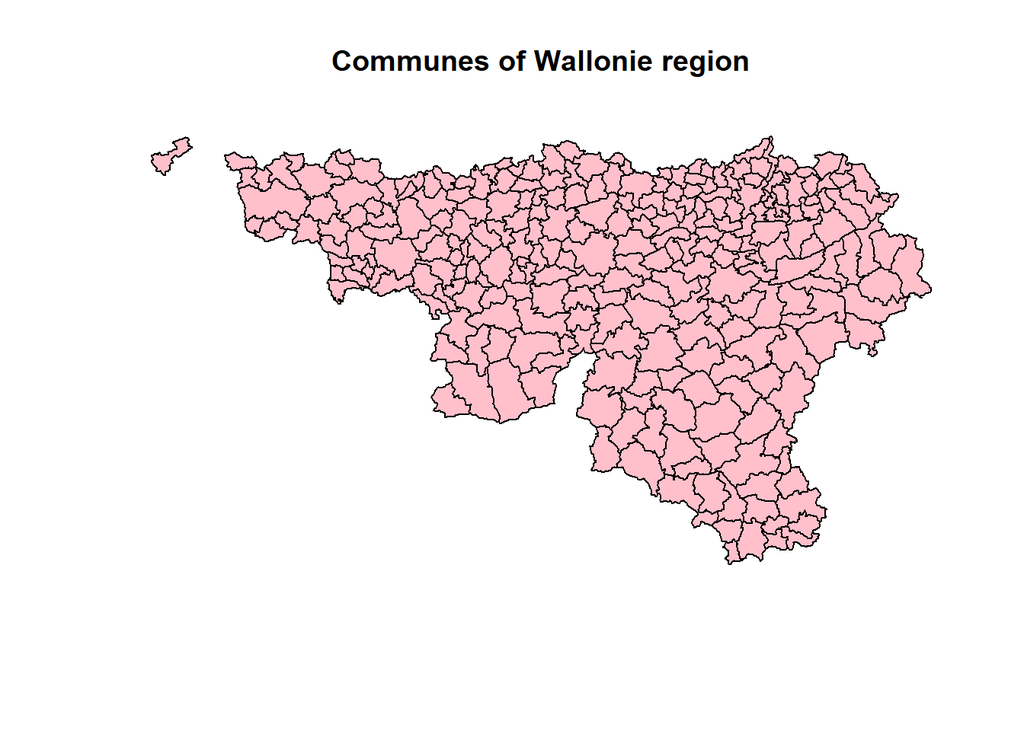

```r
plot(Wallonie_sp,col="pink", main = 'Communes of Wallonie region')
```

```r
## the important part is "projection"
proj4string(Wallonie_sp) <-CRS("+init=epsg:31300")
```

## 1.2 Cleaning the data

In this subchapter, as a cleaning data base, focus on providing data with some function that contains all the data required for analysis.

```r
#mereg the shape file with independence and dependence variable
Wa_sp_01<-merge(Wallonie_sp,c(wa_commute262,Wa_unemp,Wa_NonBelges,Wa_pop,Wa_age,Wa_life,Wa_NonBelges),
                by='Code_INS')
```

### 1.2.1 The age average in different commune

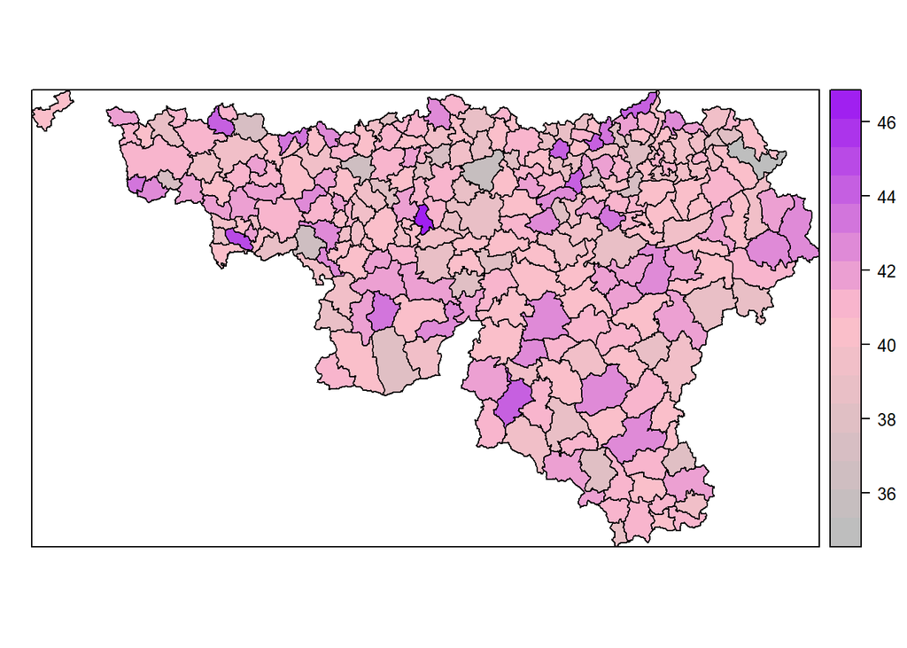

```r
#as a example of spplot for independence variable
spplot(Wa_sp_01,zcol="Age_moyen2013",col.regions=colorRampPalette(c("gray","pink","purple"))(262))
```

### 1.2.2 The choropleth maps for the unemployment rate in 2013 for Wallonie

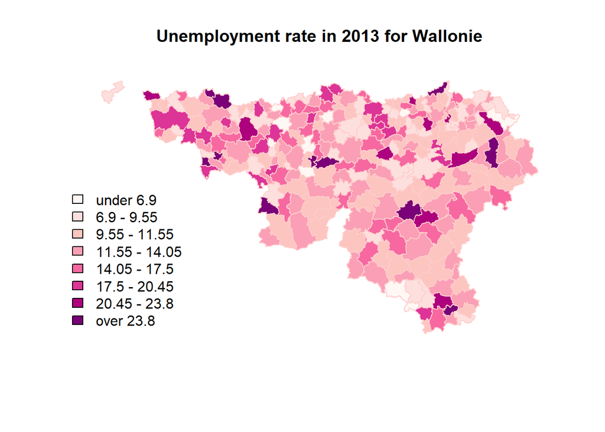

```r
choro <- function(shp, variable,cls,rang) {
var <- round(Wa_sp_01@data[, variable], digits = 2)
breaks <- classIntervals(var, n = cls, style = "fisher")$brk
my_colours <- brewer.pal(cls, rang)
plot(shp, col = my_colours[findInterval(var, breaks, all.inside = TRUE)],
axes = FALSE, border = rgb(1, 0.8, 0.8))
invisible(list(b = breaks, c = my_colours))
}
breaks <- choro(Wa_sp_01, "chomage_15_64_2013",8,"RdPu")
legend(x = 17991, y = 109072, legend = leglabs(breaks$b), fill = breaks$c, bty = "n")
title("Unemployment rate in 2013 for Wallonie")
```

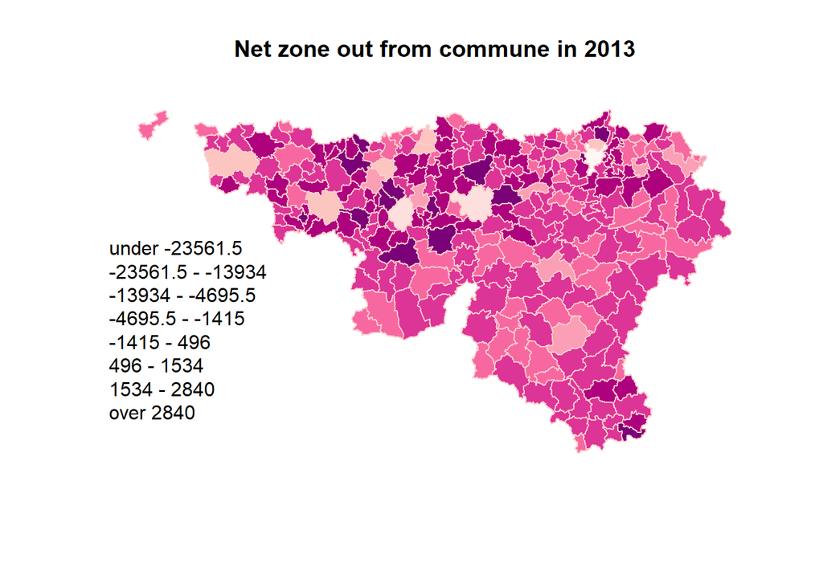

```r
choro <- function(shp, variable,cls,rang) {
var <- round(Wa_sp_01@data[, variable], digits = 2)
breaks <- classIntervals(var, n = cls, style = "fisher")$brk
my_colours <- brewer.pal(cls, rang)
plot(shp, col = my_colours[findInterval(var, breaks, all.inside = TRUE)],
axes = FALSE, border = rgb(1, 0.8, 0.8))
invisible(list(b = breaks, c = my_colours))
}
breaks <- choro(Wa_sp_01, "Net_out",8,"RdPu")
legend(x = 9000, y =119072, legend = leglabs(breaks$b), fill = breaks$c, bty = "n")
title("Net zone out from commune in 2013")
```

### 1.2.3 Compare the population and net zone out for each commune

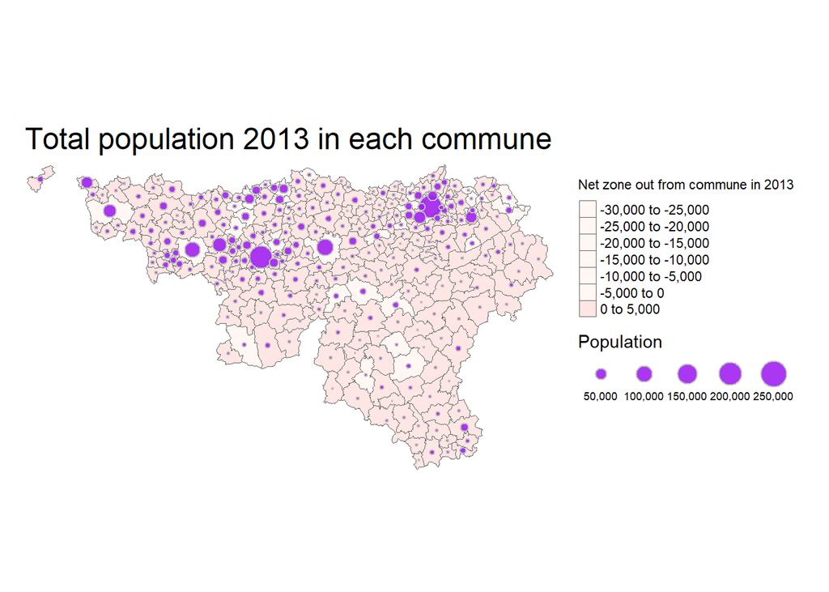

```r
 tm_shape(Wa_sp_01) +
  tm_layout(frame = F,legend.width = 0.8,
            main.title = "Total population 2013 in each commune")+
  tm_fill('Net_out', title = 'Net zone out from commune in 2013',palette = "RdPu") +tm_borders(lwd = .2)+

  tm_bubbles("Total_population_2013", "purple",alpha=0.9,
             border.col = "gray", border.alpha = 1,
        style = "fixed",breaks = c(0, 5000, 1000, 1500, 2000, 2500,3000),
             title.size = "Population")+
  tm_legend(outside = T)
```

```r
W.Dep<-c("Net_out")
W.Indep<-c("Total_population_2013","Age_moyen2013","e0_.ans.","Part_non_belges_2013",
           "chomage_15_64_2013")
```

# 2 Method

## 2.1 Descriptive analysis

### 2.1.1 univariate descriptive statistics

```r
summary(Wa_sp_01@data)
```

```
##    Code_INS            IDCOM             INSCODE              NOM1
##  Length:262         Length:262         Length:262         Length:262
##  Class :character   Class :character   Class :character   Class :character
##  Mode  :character   Mode  :character   Mode  :character   Mode  :character
##
##
##
##   NEWFIELD1             ARR               X_COORD          Y_COORD
##  Length:262         Length:262         Min.   : 48917   Min.   : 25505
##  Class :character   Class :character   1st Qu.:150664   1st Qu.:110223
##  Mode  :character   Mode  :character   Median :199813   Median :130807
##                                        Mean   :191065   Mean   :122610
##                                        3rd Qu.:234738   3rd Qu.:146749
##                                        Max.   :288261   Max.   :162818
##       AREA             PERIMETER          Out              In
##  Min.   :  7032182   Min.   :12506   Min.   :  451   Min.   :  116.0
##  1st Qu.: 30613330   1st Qu.:29692   1st Qu.: 1635   1st Qu.:  636.2
##  Median : 50914095   Median :40351   Median : 2617   Median : 1239.0
##  Mean   : 64508881   Mean   :42556   Mean   : 3918   Mean   : 3286.2
##  3rd Qu.: 86703838   3rd Qu.:53567   3rd Qu.: 4316   3rd Qu.: 2795.2
##  Max.   :215277797   Max.   :89745   Max.   :46523   Max.   :74454.0
##     Net_out           Code_INS.1    chomage_15_64_2013   Code_INS.2
##  Min.   :-27931.0   Min.   :25005   Min.   : 4.10      Min.   :25005
##  1st Qu.:   445.2   1st Qu.:55013   1st Qu.: 9.90      1st Qu.:55013
##  Median :   970.5   Median :62104   Median :11.80      Median :62104
##  Mean   :   632.2   Mean   :64188   Mean   :12.95      Mean   :64188
##  3rd Qu.:  1694.2   3rd Qu.:83030   3rd Qu.:15.00      3rd Qu.:83030
##  Max.   :  4546.0   Max.   :93090   Max.   :28.00      Max.   :93090
##  Part_non_belges_2013   Code_INS.3    Total_population_2013   Code_INS.4
##  Min.   : 1.660       Min.   :25005   Min.   :  1426        Min.   :25005
##  1st Qu.: 3.263       1st Qu.:55013   1st Qu.:  5102        1st Qu.:55013
##  Median : 4.650       Median :62104   Median :  8259        Median :62104
##  Mean   : 6.634       Mean   :64188   Mean   : 13599        Mean   :64188
##  3rd Qu.: 7.742       3rd Qu.:83030   3rd Qu.: 14532        3rd Qu.:83030
##  Max.   :48.720       Max.   :93090   Max.   :203753        Max.   :93090
##  Age_moyen2013     Code_INS.5       e0_.ans.       Code_INS.6
##  Min.   :35.30   Min.   :25005   Min.   :76.00   Min.   :25005
##  1st Qu.:39.62   1st Qu.:55013   1st Qu.:79.30   1st Qu.:55013
##  Median :40.50   Median :62104   Median :80.00   Median :62104
##  Mean   :40.49   Mean   :64188   Mean   :80.06   Mean   :64188
##  3rd Qu.:41.30   3rd Qu.:83030   3rd Qu.:80.90   3rd Qu.:83030
##  Max.   :46.10   Max.   :93090   Max.   :83.80   Max.   :93090
##  Part_non_belges_2013.1
##  Min.   : 1.660
##  1st Qu.: 3.263
##  Median : 4.650
##  Mean   : 6.634
##  3rd Qu.: 7.742
##  Max.   :48.720
```

```r
str(Wa_sp_01@data)
```

```
## 'data.frame':    262 obs. of  25 variables:
##  $ Code_INS              : chr  "25005" "25014" "25015" "25018" ...
##  $ IDCOM                 : chr  "155" "156" "157" "158" ...
##  $ INSCODE               : chr  "25005" "25014" "25015" "25018" ...
##  $ NOM1                  : chr  "BEAUVECHAIN" "BRAINE-L'ALLEUD" "BRAINE-LE-CHATEAU" "CHAUMONT-GISTOUX" ...
##  $ NEWFIELD1             : chr  "25005" "25014" "25015" "25018" ...
##  $ ARR                   : chr  "25" "25" "25" "25" ...
##  $ X_COORD               : num  178101 149136 144112 173219 163646 ...
##  $ Y_COORD               : num  162587 152161 152130 153045 146249 ...
##  $ AREA                  : num  38713309 52497508 22765210 48549944 26791957 ...
##  $ PERIMETER             : num  29854 44843 21071 37483 27081 ...
##  $ Out                   : num  2261 11952 3219 3347 3273 ...
##  $ In                    : num  2321 13200 2326 985 1463 ...
##  $ Net_out               : num  -60 -1248 893 2362 1810 ...
##  $ Code_INS.1            : int  25005 25014 25015 25018 25023 25031 25037 25043 25044 25048 ...
##  $ chomage_15_64_2013    : num  19 16.5 4.4 15.3 19.3 11.6 18 9.6 13.2 12 ...
##  $ Code_INS.2            : int  25005 25014 25015 25018 25023 25031 25037 25043 25044 25048 ...
##  $ Part_non_belges_2013  : num  5.58 9.07 6.85 5.87 6.95 5.49 6.46 4.21 6.38 5.24 ...
##  $ Code_INS.3            : int  25005 25014 25015 25018 25023 25031 25037 25043 25044 25048 ...
##  $ Total_population_2013 : int  6868 39250 9991 11654 10066 15160 12876 4964 6478 13614 ...
##  $ Code_INS.4            : int  25005 25014 25015 25018 25023 25031 25037 25043 25044 25048 ...
##  $ Age_moyen2013         : num  41 40.3 41.2 39.9 41.5 41.2 42.3 40.6 40.7 39.1 ...
##  $ Code_INS.5            : int  25005 25014 25015 25018 25023 25031 25037 25043 25044 25048 ...
##  $ e0_.ans.              : num  81.8 81.9 80.8 82.2 81.2 80.8 82.1 82.9 80.6 81.6 ...
##  $ Code_INS.6            : int  25005 25014 25015 25018 25023 25031 25037 25043 25044 25048 ...
##  $ Part_non_belges_2013.1: num  5.58 9.07 6.85 5.87 6.95 5.49 6.46 4.21 6.38 5.24 ...
```

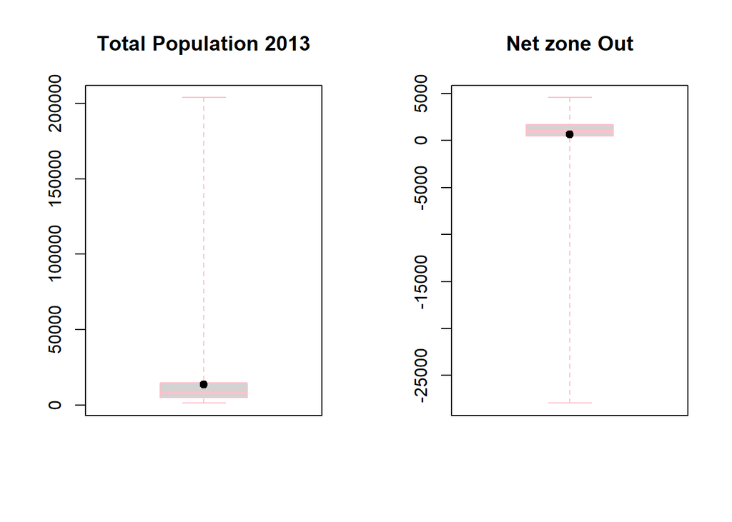

```r
par(mfrow = c(1,2))
boxplot(Wa_sp_01@data$Total_population_2013, main = "Total Population 2013", range = 0, border = 'pink')
points(mean(Wa_sp_01@data$Total_population_2013), col = 1, pch = 19)


boxplot(Wa_sp_01@data$Net_out, main = "Net zone Out", range = 0, border = 'pink')
points(mean(Wa_sp_01@data$Net_out), col = 1, pch = 19)
```

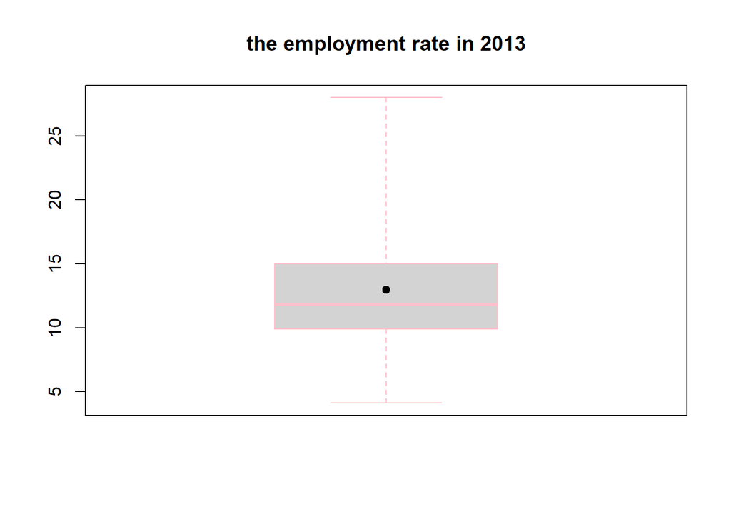

```r
boxplot(Wa_sp_01@data$chomage_15_64_2013, main = "the employment rate in 2013", range = 0, border = 'pink')
points(mean(Wa_sp_01@data$chomage_15_64_2013), col = 1, pch = 19)
```

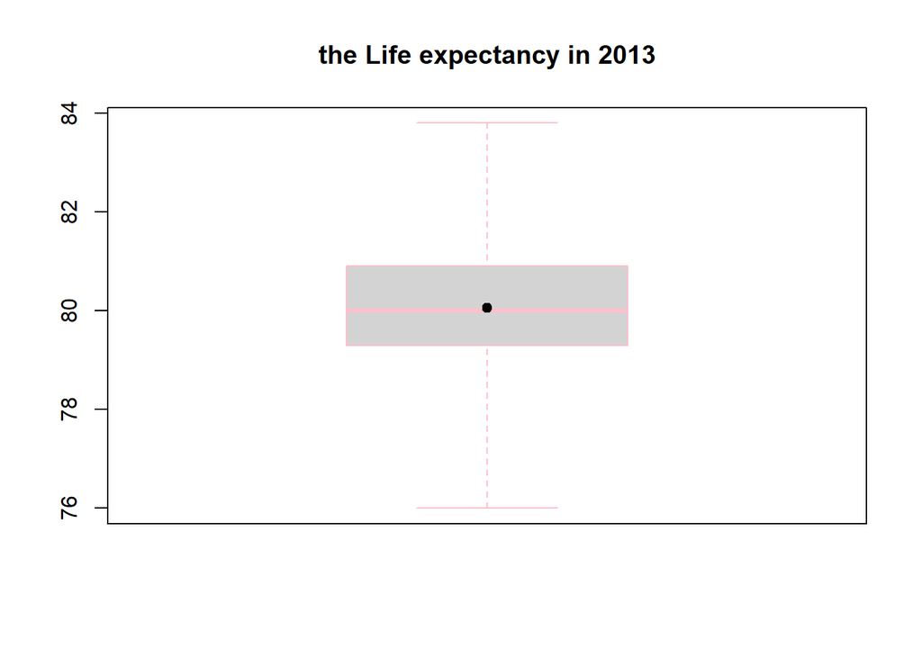

```r
boxplot(Wa_sp_01@data$e0_.ans., main = "the Life expectancy in 2013", range = 0, border = 'pink')
points(mean(Wa_sp_01@data$e0_.ans.), col = 1, pch = 19)
```

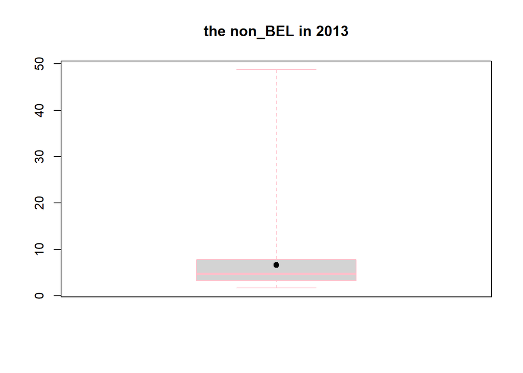

```r
boxplot(Wa_sp_01@data$Part_non_belges_2013, main = "the non_BEL in 2013", range = 0, border = 'pink')
points(mean(Wa_sp_01@data$Part_non_belges_2013), col = 1, pch = 19)
```

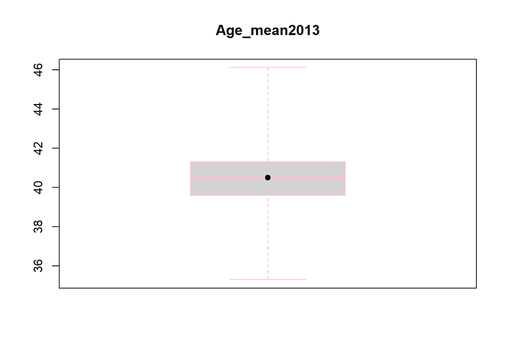

```r
boxplot(Wa_sp_01@data$Age_moyen2013 , main = "Age_mean2013", range = 0, border = 'pink')
points(mean(Wa_sp_01@data$Age_moyen2013 ), col = 1, pch = 19)
```

### Considering the normality of the net zone out

There is no normal distribution in the histogram and Q-Q plot for net zoning out. At an alpha of 0.01 percent, the Shapiro test has a very small p value of 2.2e-16. So, indicating that it does not have a normal distribution.

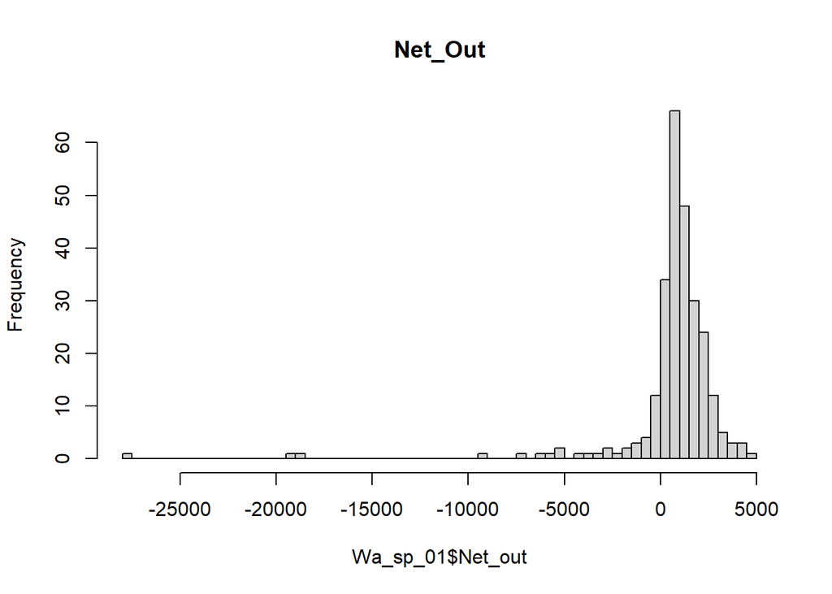

```r
hist(Wa_sp_01$Net_out,breaks=50,main="Net_Out")
```

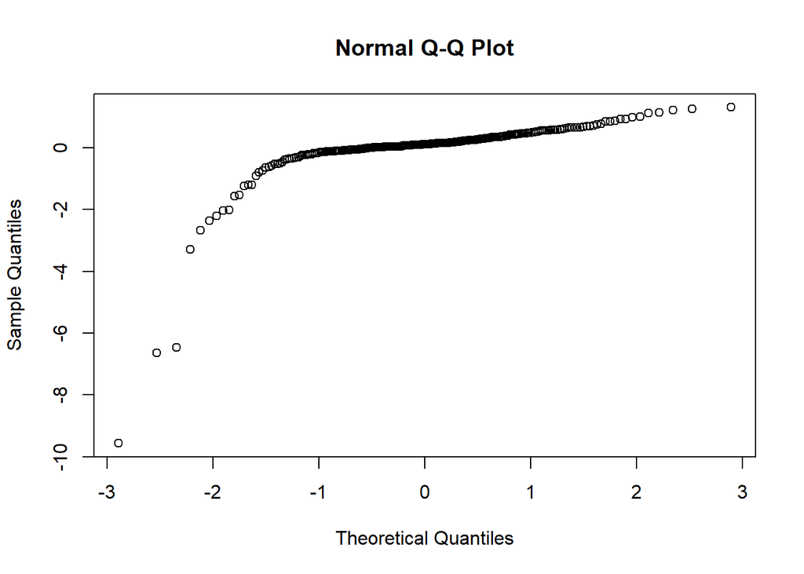

```r
qqnorm(scale(Wa_sp_01$Net_out))
```

```r
shapiro.test(Wa_sp_01$Net_out)
```

```
##
##  Shapiro-Wilk normality test
##
## data:  Wa_sp_01$Net_out
## W = 0.49027, p-value < 2.2e-16
```

### 2.1.2 Bivariate descriptive statistics

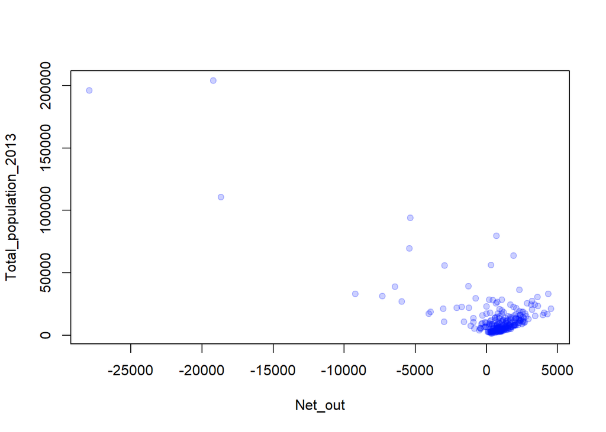

```r
plot(Wa_sp_01@data$Net_out,Wa_sp_01@data$Total_population_2013, col = topo.colors(90, .2)[10],
     pch = 19,xlab="Net_out",
     ylab="Total_population_2013")
```

## Spatial autocorrelation and spatial regression

In this part,the aim was consideration of Spatial autocorrelation.

## 2.2 Spatial Autocorrelation

```r
#Computing Local Moran’s I
coordWa<-coordinates(Wa_sp_01)
#contQWa<-poly2nb(Wa_sp_01)
Wa_kn8<-knn2nb(knearneigh(coordWa,k=8))
#cont_WM<- nb2listw(contQWa_sp_01,zero.policy = TRUE)
kn8_WM<-nb2listw(Wa_kn8)
```

### 2.2.1 Moran test of the independent variable

```r
moranI_unemploymentrate<-moran.test(Wa_sp_01$chomage_15_64_2013,listw = kn8_WM,zero.policy = T)
moranI_unemploymentrate
```

```
##
##  Moran I test under randomisation
##
## data:  Wa_sp_01$chomage_15_64_2013
## weights: kn8_WM
##
## Moran I statistic standard deviate = 0.067732, p-value = 0.473
## alternative hypothesis: greater
## sample estimates:
## Moran I statistic       Expectation          Variance
##      -0.001862570      -0.003831418       0.000844964
```

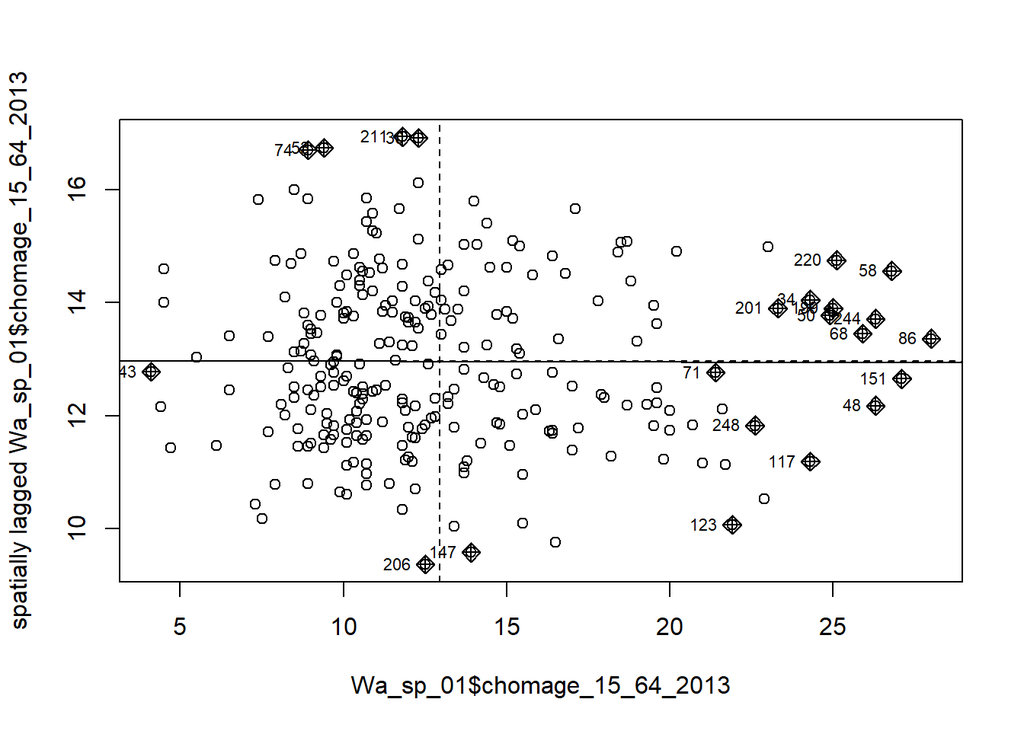

```r
moran.plot(Wa_sp_01$chomage_15_64_2013,listw = kn8_WM,zero.policy = T)
```

LISA (or Local Moran) is the result of the lag and the variable itself (normalized). LISA values can be easily determined using the Moran scatterplot.The red color shows high and blue color shows low souurounded with the same value of neighbourhood.So, The red color represents high and the blue color represents low value that surroundings with the neighborhood with same value.

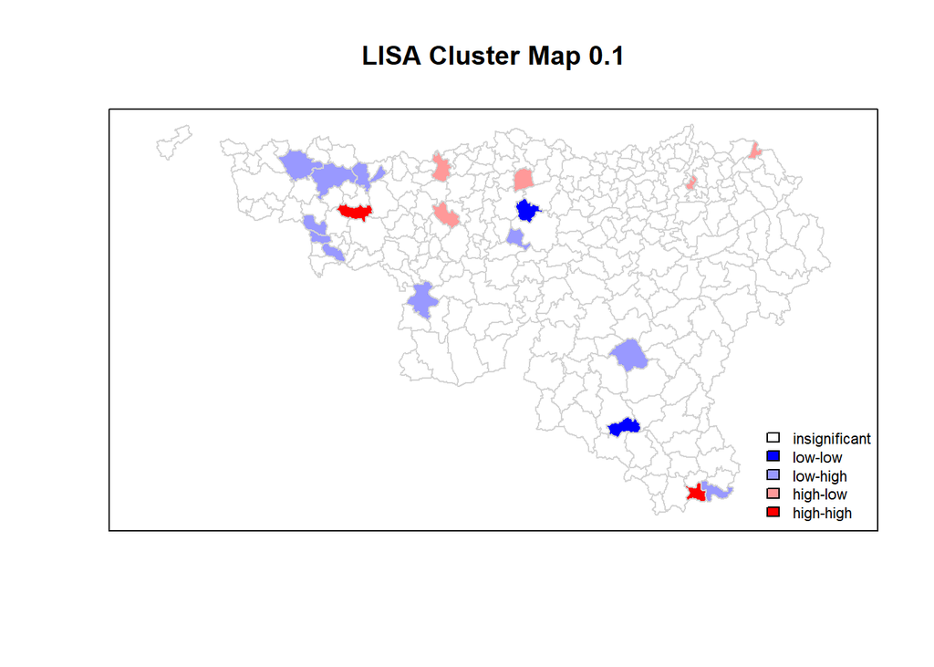

```r
dev_unemploymentrate<-Wa_sp_01$chomage_15_64_2013-mean(Wa_sp_01$chomage_15_64_2013) #express variable as deviation to mean
spatial_lag_dev_unemploymentrate<-lag.listw(kn8_WM,dev_unemploymentrate) #lag the deviation to mean
#morlm <- lm(spatial_lag_dev_x ~ dev_x)
#morlm_itcpt<- morlm$coefficients[1]
#morlm_i <- morlm$coefficients[2] #retrieves the slope
#morlm_i
lm_dev_unemploymentrate<-localmoran(Wa_sp_01$chomage_15_64_2013,listw = kn8_WM,zero.policy = T)
lisa_dev_unemploymentrate<-as.data.frame(lm_dev_unemploymentrate)
quad_dev_unemploymentrate <- vector(mode="numeric",length=length(Wa_sp_01$Net_out))
quad_dev_unemploymentrate[dev_unemploymentrate <0 & spatial_lag_dev_unemploymentrate<0] <- 1 #LL
quad_dev_unemploymentrate[dev_unemploymentrate <0 & spatial_lag_dev_unemploymentrate>0] <- 2 #LH
quad_dev_unemploymentrate[dev_unemploymentrate >0 & spatial_lag_dev_unemploymentrate<0] <- 3 #HL
quad_dev_unemploymentrate[dev_unemploymentrate >0 &spatial_lag_dev_unemploymentrate>0] <- 4 #HH

lisa_dev_unemploymentrate$quad<-quad_dev_unemploymentrate
# statistical significance level
signif <- 0.1

lisa_dev_unemploymentrate$signif_quad<-quad_dev_unemploymentrate
lisa_dev_unemploymentrate$signif_quad[lisa_dev_unemploymentrate[,5]>signif]<-0

brks <- c(0,1,2,3,4)
colorsLISA <- c("white","blue",rgb(0,0,1,alpha=0.4),rgb(1,0,0,alpha=0.4),"red")
colorsLISA_each<-colorsLISA[findInterval(lisa_dev_unemploymentrate$signif_quad,brks,all.inside=FALSE)]
plot(Wa_sp_01,border="lightgray",col=colorsLISA_each)
box()
legend("bottomright", legend=c("insignificant","low-low","low-high","high-low","high-high"),
       fill=colorsLISA,
       bty="n", cex=0.7,y.intersp=1,x.intersp=1)

title(paste("LISA Cluster Map", signif))
```

```r
moranI_commute<-moran.test(Wa_sp_01$Net_out,listw = kn8_WM,zero.policy = T)
moranI_commute
```

```
##
##  Moran I test under randomisation
##
## data:  Wa_sp_01$Net_out
## weights: kn8_WM
##
## Moran I statistic standard deviate = -0.94409, p-value = 0.8274
## alternative hypothesis: greater
## sample estimates:
## Moran I statistic       Expectation          Variance
##     -0.0288386454     -0.0038314176      0.0007016226
```

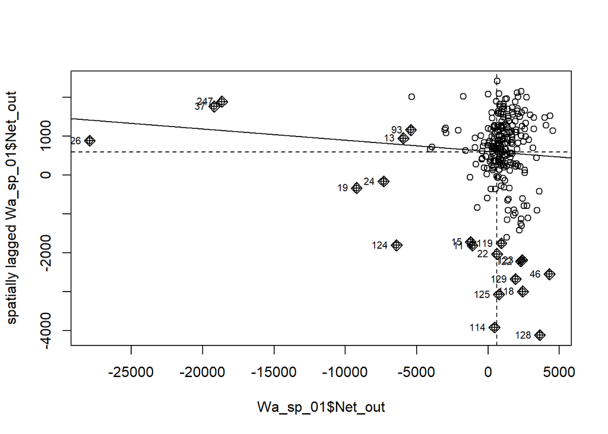

```r
moran.plot(Wa_sp_01$Net_out,listw = kn8_WM,zero.policy = T)
```

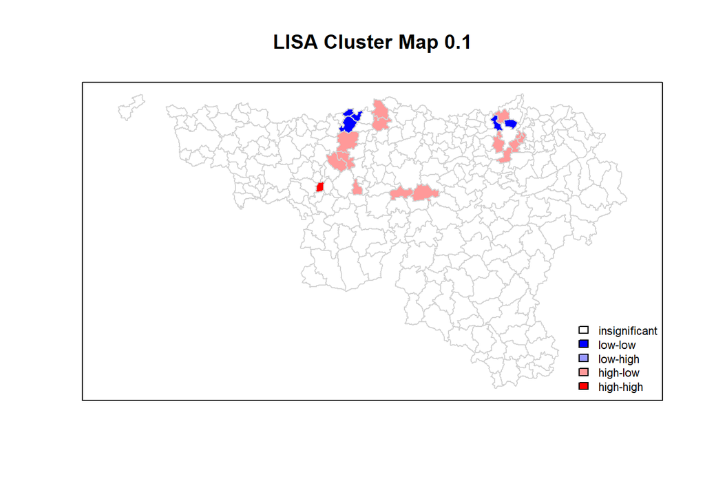

```r
dev_Commute<-Wa_sp_01$Net_out-mean(Wa_sp_01$Net_out) #express variable as deviation to mean
spatial_lag_dev_Commute<-lag.listw(kn8_WM,dev_Commute) #lag the deviation to mean
#morlm <- lm(spatial_lag_dev_x ~ dev_x)
#morlm_itcpt<- morlm$coefficients[1]
#morlm_i <- morlm$coefficients[2] #retrieves the slope
#morlm_i
lm_Commute<-localmoran(Wa_sp_01$Net_out,listw = kn8_WM,zero.policy = T)
lisa_Commute<-as.data.frame(lm_Commute)
quad_Commute <- vector(mode="numeric",length=length(Wa_sp_01$Net_out))
quad_Commute[dev_Commute <0 & spatial_lag_dev_Commute<0] <- 1 #LL
quad_Commute[dev_Commute <0 & spatial_lag_dev_Commute>0] <- 2 #LH
quad_Commute[dev_Commute >0 & spatial_lag_dev_Commute<0] <- 3 #HL
quad_Commute[dev_Commute >0 &spatial_lag_dev_Commute>0] <- 4 #HH

lisa_Commute$quad<-quad_Commute
# statistical significance level
signif <- 0.1

lisa_Commute$signif_quad<-quad_Commute
lisa_Commute$signif_quad[lisa_Commute[,5]>signif]<-0

brks <- c(0,1,2,3,4)
colorsLISA <- c("white","blue",rgb(0,0,1,alpha=0.4),rgb(1,0,0,alpha=0.4),"red")
colorsLISA_each<-colorsLISA[findInterval(lisa_Commute$signif_quad,brks,all.inside=FALSE)]
plot(Wa_sp_01,border="lightgray",col=colorsLISA_each)
box()
legend("bottomright", legend=c("insignificant","low-low","low-high","high-low","high-high"),
       fill=colorsLISA,
       bty="n", cex=0.7,y.intersp=1,x.intersp=1)

title(paste("LISA Cluster Map", signif))
```

```r
saveGIF(movie.name = "lisanimCommute.gif",interval=0.5,
  for (signif in c(seq(0.01,0.1,by=0.01),
                   seq(0.125,0.5,by=0.025),
                   seq(0.6,1,by=0.1))) {
  lisa_Commute$signif_quad<-quad_Commute
  lisa_Commute$signif_quad[lisa_Commute[,5]>signif]<-0
  WaLISA<-Wa_sp_01
  WaLISA$signif_quad<-lisa_Commute$signif_quad

  #generate gift for illustrating the significant level in communes
  print(
    tm_shape(WaLISA) +
      tm_fill("signif_quad",
              palette=colorsLISA,
              style='fixed',
              breaks=c(0,0.9,1.9,2.9,3.9,4.1),
              labels=c(paste("not signif. (p>",signif,")",sep=""),
                       "low-low","low-high","high-low","high-high"),
              legend.reverse=T,
              title="LISA")+
      tm_shape(Wa_sp_01)+
      tm_layout(frame=F,
                legend.text.size = 1,
                legend.title.size = 2,
                bg.color = "gray62")+
      tm_borders("pink", lwd=1)
  )
}
)
```

```
## [1] TRUE
```

### 2.2.2 Lisa map in significant different level

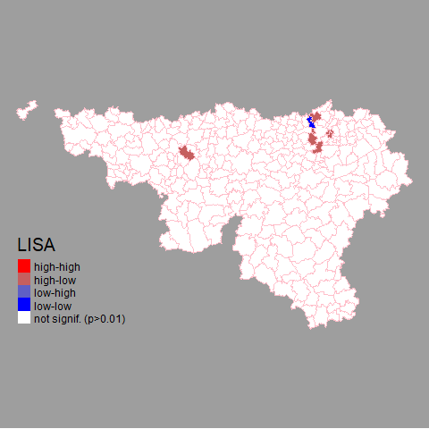

```r
knitr::include_graphics('lisanimCommute.gif')
```

### Checking for normality and multi-collinearity

The Shapiro-Wilk normality test should result p > 0.05 for the distribution to be normal. The command cor allows for the calculation of the Pearson Correlation Coefficients.so, p-value < 2.2e-16 shows that the the distribution is not normal.

```r
dep_var<-Wa_sp_01@data$Net_out
expl_vars<- data.frame(Wa_pop=Wa_sp_01@data$Total_population_2013,Wa_unemp=Wa_sp_01@data$chomage_15_64_2013,Wa_age=Wa_sp_01@data$Age_moyen2013,Wa_NonBelges=Wa_sp_01@data$Part_non_belges_2013,
Wa_life=Wa_sp_01@data$e0_.ans.)

shapiro.test(dep_var)
```

```
##
##  Shapiro-Wilk normality test
##
## data:  dep_var
## W = 0.49027, p-value < 2.2e-16
```

we use the “corrgram” and “VIF”for checking the multi-collinearity between variable. No evidence of multicollinearity between all independent variables.

[figure not shown]

```r
corrgram(expl_vars,upper.panel = panel.cor, cor.method = "pearson")
```

```r
model_01<- lm(Wa_sp_01$Net_out~ Wa_sp_01$chomage_15_64_2013+Wa_sp_01$Total_population_2013+Wa_sp_01$Age_moyen2013+Wa_sp_01$Age_moyen2013+Wa_sp_01$Part_non_belges_2013+Wa_sp_01$e0_.ans.,na.action = na.omit)
#Testing for multicollinearity issues
vif(model_01)
```

```
##    Wa_sp_01$chomage_15_64_2013 Wa_sp_01$Total_population_2013
##                       1.052264                       1.164376
##         Wa_sp_01$Age_moyen2013  Wa_sp_01$Part_non_belges_2013
##                       1.052761                       1.141730
##              Wa_sp_01$e0_.ans.
##                       1.024201
```

## 2.3 Ordinary least-squares (OLS) model

According to this model, the unemployment rate, age average, and life expectancy have no significant impact at the confidence level of 95%.And, the total population has a significant impact at the confidence level of 99%.

According to the coefficients of the model, we can say that: by having controll on other variables when he population increases by 1 unit, the difference between zoning out and zoning in Wallonia’s commune decrease by 1.122e-01.

Also, by having controll on other variables when the percentage of non_Belgian increases by 1 %, the difference between zoning out and zoning in Wallonia’s commune increase by 5.682e+01.

as well as this model The considered (and significant) variables explain approximately 58 percent of net zoning out.

```r
model_01<- lm(Wa_sp_01$Net_out~ Wa_sp_01$chomage_15_64_2013+Wa_sp_01$Total_population_2013+Wa_sp_01$Age_moyen2013+Wa_sp_01$Age_moyen2013+Wa_sp_01$Part_non_belges_2013+Wa_sp_01$e0_.ans.,na.action = na.omit)
summary(model_01)
```

```
##
## Call:
## lm(formula = Wa_sp_01$Net_out ~ Wa_sp_01$chomage_15_64_2013 +
##     Wa_sp_01$Total_population_2013 + Wa_sp_01$Age_moyen2013 +
##     Wa_sp_01$Age_moyen2013 + Wa_sp_01$Part_non_belges_2013 +
##     Wa_sp_01$e0_.ans., na.action = na.omit)
##
## Residuals:
##     Min      1Q  Median      3Q     Max
## -8600.8  -910.3  -224.2   977.6  6551.6
##
## Coefficients:
##                                  Estimate Std. Error t value Pr(>|t|)
## (Intercept)                     6.718e+03  8.462e+03   0.794   0.4280
## Wa_sp_01$chomage_15_64_2013     1.723e+01  2.666e+01   0.646   0.5187
## Wa_sp_01$Total_population_2013 -1.122e-01  6.134e-03 -18.299   <2e-16 ***
## Wa_sp_01$Age_moyen2013          1.494e+02  7.859e+01   1.901   0.0584 .
## Wa_sp_01$Part_non_belges_2013   5.682e+01  2.251e+01   2.524   0.0122 *
## Wa_sp_01$e0_.ans.              -1.400e+02  9.572e+01  -1.463   0.1448
## ---
## Signif. codes:  0 '***' 0.001 '**' 0.01 '*' 0.05 '.' 0.1 ' ' 1
##
## Residual standard error: 1936 on 256 degrees of freedom
## Multiple R-squared:  0.5876, Adjusted R-squared:  0.5796
## F-statistic: 72.96 on 5 and 256 DF,  p-value: < 2.2e-16
```

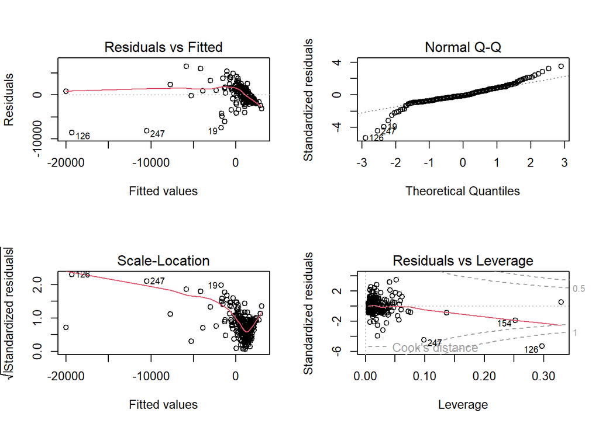

```r
#Diagnostic plot
par(mfrow=c(2,2)) #plot layout
plot(model_01)
```

# Testing for residuals’ heteroskedasticity

The Pvalue shows that Homoskedasticity assumption rejected!

```r
#Testing for residuals’ heteroskedasticity

bptest<-bptest(model_01)
print(bptest)
```

```
##
##  studentized Breusch-Pagan test
##
## data:  model_01
## BP = 99.26, df = 5, p-value < 2.2e-16
```

## 2.4 Spatial dependence tests

In the presence of spatial dependence, the results of Ordinary Least Squares estimation are skewed. As a result, the aim was the considering spatial potential indirect effects on the dependent variables, which were previously redacted from the linear regression.

```r
#Mapping residuals
#Add the residuals to the spatial dataframe
Wa_sp_01$residmodel_0<-resid(model_01)
```

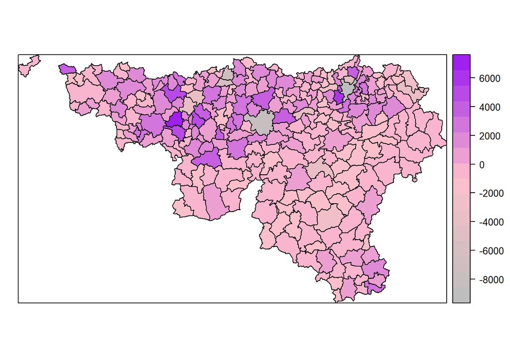

```r
#Plot residuals
Wa_sp_01@data$resOLS<-resid(model_01)

spplot(Wa_sp_01,zcol="resOLS",col.regions=colorRampPalette(c("gray","pink","purple"))(262))
```

```r
#Computing Local Moran’s I of OLS residuals
moranI_resOLS<-moran.test(Wa_sp_01$resOLS,listw = kn8_WM,zero.policy = T)
moranI_resOLS
```

```
##
##  Moran I test under randomisation
##
## data:  Wa_sp_01$resOLS
## weights: kn8_WM
##
## Moran I statistic standard deviate = 3.4153, p-value = 0.0003186
## alternative hypothesis: greater
## sample estimates:
## Moran I statistic       Expectation          Variance
##      0.0948962020     -0.0038314176      0.0008356497
```

```r
#Significant positive spatial autocorrelation in the residuals
```

## 2.5 Local Moran and LISA Cluster Map

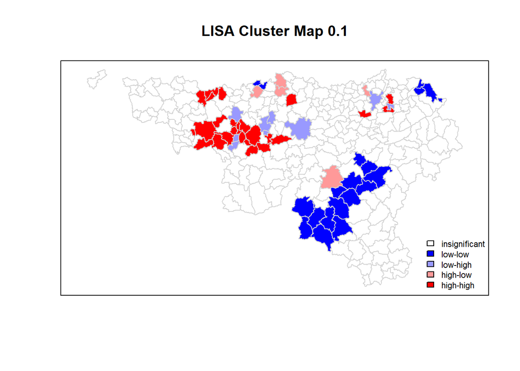

```r
dev_Commute<-Wa_sp_01$resOLS-mean(Wa_sp_01$resOLS) #express variable as deviation to mean
spatial_lag_dev_Commute<-lag.listw(kn8_WM,dev_Commute) #lag the deviation to mean
#morlm <- lm(spatial_lag_dev_x ~ dev_x)
#morlm_itcpt<- morlm$coefficients[1]
#morlm_i <- morlm$coefficients[2] #retrieves the slope
#morlm_i
lm_Commute<-localmoran(Wa_sp_01$resOLS,listw = kn8_WM,zero.policy = T)
lisa_Commute<-as.data.frame(lm_Commute)
quad_Commute <- vector(mode="numeric",length=length(Wa_sp_01$resOLS))
quad_Commute[dev_Commute <0 & spatial_lag_dev_Commute<0] <- 1 #LL
quad_Commute[dev_Commute <0 & spatial_lag_dev_Commute>0] <- 2 #LH
quad_Commute[dev_Commute >0 & spatial_lag_dev_Commute<0] <- 3 #HL
quad_Commute[dev_Commute >0 &spatial_lag_dev_Commute>0] <- 4 #HH

lisa_Commute$quad<-quad_Commute
# statistical significance level
signif <- 0.1

lisa_Commute$signif_quad<-quad_Commute
lisa_Commute$signif_quad[lisa_Commute[,5]>signif]<-0

brks <- c(0,1,2,3,4)
colorsLISA <- c("white","blue",rgb(0,0,1,alpha=0.4),rgb(1,0,0,alpha=0.4),"red")
colorsLISA_each<-colorsLISA[findInterval(lisa_Commute$signif_quad,brks,all.inside=FALSE)]
plot(Wa_sp_01,border="lightgray",col=colorsLISA_each)
box()
legend("bottomright", legend=c("insignificant","low-low","low-high","high-low","high-high"),
       fill=colorsLISA,
       bty="n", cex=0.7,y.intersp=1,x.intersp=1)

title(paste("LISA Cluster Map", signif))
```

# 3 spatial chractrestic of variable

there is two way for considering the results of the Moran’s I test on the dependent variable: 1.spatial dependency 2.spatial heterogeneity

## 3.1 Lagrange multiplier diagnostics for spatial dependence

LMerr = 10.249, df = 1, p-value = 0.001367——–> p-value is smaller than alpha=0.01, This result demonstrates that the two Moran’ I result tests are correct. and residuals are spatially dependent.

RLMerr = 32.655, df = 1, p-value = 1.1e-08——–> p-value is smaller than alpha=0.01.So, there is spatialy dependency in errors.

LMlag = 1.865, df = 1, p-value = 0.172————> p-value is larger than alpha=0.01.So, there is not a spatial dependency.

```r
LMOLS <-lm.LMtests(model_01,kn8_WM,test=c("LMerr", "RLMerr","LMlag","RLMlag", "SARMA"),zero.policy = T)
LMOLS
```

```
##
##  Lagrange multiplier diagnostics for spatial dependence
##
## data:
## model: lm(formula = Wa_sp_01$Net_out ~ Wa_sp_01$chomage_15_64_2013 +
## Wa_sp_01$Total_population_2013 + Wa_sp_01$Age_moyen2013 +
## Wa_sp_01$Age_moyen2013 + Wa_sp_01$Part_non_belges_2013 +
## Wa_sp_01$e0_.ans., na.action = na.omit)
## weights: kn8_WM
##
## LMerr = 10.249, df = 1, p-value = 0.001367
##
##
##  Lagrange multiplier diagnostics for spatial dependence
##
## data:
## model: lm(formula = Wa_sp_01$Net_out ~ Wa_sp_01$chomage_15_64_2013 +
## Wa_sp_01$Total_population_2013 + Wa_sp_01$Age_moyen2013 +
## Wa_sp_01$Age_moyen2013 + Wa_sp_01$Part_non_belges_2013 +
## Wa_sp_01$e0_.ans., na.action = na.omit)
## weights: kn8_WM
##
## RLMerr = 32.655, df = 1, p-value = 1.1e-08
##
##
##  Lagrange multiplier diagnostics for spatial dependence
##
## data:
## model: lm(formula = Wa_sp_01$Net_out ~ Wa_sp_01$chomage_15_64_2013 +
## Wa_sp_01$Total_population_2013 + Wa_sp_01$Age_moyen2013 +
## Wa_sp_01$Age_moyen2013 + Wa_sp_01$Part_non_belges_2013 +
## Wa_sp_01$e0_.ans., na.action = na.omit)
## weights: kn8_WM
##
## LMlag = 1.865, df = 1, p-value = 0.172
##
##
##  Lagrange multiplier diagnostics for spatial dependence
##
## data:
## model: lm(formula = Wa_sp_01$Net_out ~ Wa_sp_01$chomage_15_64_2013 +
## Wa_sp_01$Total_population_2013 + Wa_sp_01$Age_moyen2013 +
## Wa_sp_01$Age_moyen2013 + Wa_sp_01$Part_non_belges_2013 +
## Wa_sp_01$e0_.ans., na.action = na.omit)
## weights: kn8_WM
##
## RLMlag = 24.271, df = 1, p-value = 8.369e-07
##
##
##  Lagrange multiplier diagnostics for spatial dependence
##
## data:
## model: lm(formula = Wa_sp_01$Net_out ~ Wa_sp_01$chomage_15_64_2013 +
## Wa_sp_01$Total_population_2013 + Wa_sp_01$Age_moyen2013 +
## Wa_sp_01$Age_moyen2013 + Wa_sp_01$Part_non_belges_2013 +
## Wa_sp_01$e0_.ans., na.action = na.omit)
## weights: kn8_WM
##
## SARMA = 34.52, df = 2, p-value = 3.192e-08
```

### 3.1.1 Spatial Error Model (SEM)

```r
SEM <- errorsarlm(Wa_sp_01$Net_out~Wa_sp_01$Total_population_2013+Wa_sp_01$Age_moyen2013+Wa_sp_01$Age_moyen2013+Wa_sp_01$Part_non_belges_2013+Wa_sp_01$e0_.ans., listw=kn8_WM,zero.policy = T )
summary(SEM)
```

```
##
## Call:errorsarlm(formula = Wa_sp_01$Net_out ~ Wa_sp_01$Total_population_2013 +
##     Wa_sp_01$Age_moyen2013 + Wa_sp_01$Age_moyen2013 + Wa_sp_01$Part_non_belges_2013 +
##     Wa_sp_01$e0_.ans., listw = kn8_WM, zero.policy = T)
##
## Residuals:
##      Min       1Q   Median       3Q      Max
## -8001.01  -909.01  -211.13   934.61  6799.93
##
## Type: error
## Coefficients: (asymptotic standard errors)
##                                   Estimate  Std. Error  z value Pr(>|z|)
## (Intercept)                    -4.8710e+02  9.0387e+03  -0.0539  0.95702
## Wa_sp_01$Total_population_2013 -1.1843e-01  5.9567e-03 -19.8826  < 2e-16
## Wa_sp_01$Age_moyen2013          1.7045e+02  7.3059e+01   2.3331  0.01964
## Wa_sp_01$Part_non_belges_2013   5.2375e+01  2.4230e+01   2.1616  0.03065
## Wa_sp_01$e0_.ans.              -5.6579e+01  1.0523e+02  -0.5376  0.59082
##
## Lambda: 0.35269, LR test value: 9.4231, p-value: 0.0021427
## Asymptotic standard error: 0.10164
##     z-value: 3.47, p-value: 0.00052052
## Wald statistic: 12.041, p-value: 0.00052052
##
## Log likelihood: -2347.151 for error model
## ML residual variance (sigma squared): 3485500, (sigma: 1867)
## Number of observations: 262
## Number of parameters estimated: 7
## AIC: 4708.3, (AIC for lm: 4715.7)
```

# 4 Testing for residuals’ heteroskedasticity:

The Pvalue shows that Homoskedasticity assumption rejected!

```r
bptest.Sarlm(SEM)
```

```
##
##  studentized Breusch-Pagan test
##
## data:
## BP = 92.42, df = 4, p-value < 2.2e-16
```

### 4.0.1 Spatial autoregressive model (SAR)

```r
SAR<-lagsarlm(Wa_sp_01$Net_out~Wa_sp_01$Total_population_2013+Wa_sp_01$Age_moyen2013+Wa_sp_01$Age_moyen2013+Wa_sp_01$Part_non_belges_2013+Wa_sp_01$e0_.ans., listw= kn8_WM,zero.policy = T)
summary(SAR)
```

```
##
## Call:lagsarlm(formula = Wa_sp_01$Net_out ~ Wa_sp_01$Total_population_2013 +
##     Wa_sp_01$Age_moyen2013 + Wa_sp_01$Age_moyen2013 + Wa_sp_01$Part_non_belges_2013 +
##     Wa_sp_01$e0_.ans., listw = kn8_WM, zero.policy = T)
##
## Residuals:
##      Min       1Q   Median       3Q      Max
## -8617.90  -952.53  -153.10  1028.87  6821.15
##
## Type: lag
## Coefficients: (numerical Hessian approximate standard errors)
##                                   Estimate  Std. Error  z value Pr(>|z|)
## (Intercept)                     9.2534e+03  8.4187e+03   1.0991  0.27171
## Wa_sp_01$Total_population_2013 -1.1160e-01  6.0302e-03 -18.5061  < 2e-16
## Wa_sp_01$Age_moyen2013          1.6552e+02  7.5535e+01   2.1913  0.02843
## Wa_sp_01$Part_non_belges_2013   5.1310e+01  2.2324e+01   2.2984  0.02154
## Wa_sp_01$e0_.ans.              -1.7553e+02  9.5627e+01  -1.8356  0.06642
##
## Rho: -0.16065, LR test value: 2.4561, p-value: 0.11707
## Approximate (numerical Hessian) standard error: 0.10257
##     z-value: -1.5663, p-value: 0.11728
## Wald statistic: 2.4533, p-value: 0.11728
##
## Log likelihood: -2350.634 for lag model
## ML residual variance (sigma squared): 3624800, (sigma: 1903.9)
## Number of observations: 262
## Number of parameters estimated: 7
## AIC: 4715.3, (AIC for lm: 4715.7)
```

Testing for residuals’ heteroskedasticity:

The Pvalue shows that Homoskedasticity assumption rejected!

```r
bptest.Sarlm(SAR)
```

```
##
##  studentized Breusch-Pagan test
##
## data:
## BP = 99.81, df = 4, p-value < 2.2e-16
```

### 4.0.2 Spatial Simultaneous Autoregressive Model (SAC)

```r
SAC<-sacsarlm(Wa_sp_01$Net_out ~Wa_sp_01$Total_population_2013+Wa_sp_01$Age_moyen2013+Wa_sp_01$Age_moyen2013+Wa_sp_01$Part_non_belges_2013+Wa_sp_01$e0_.ans., listw=kn8_WM,zero.policy = T,listw2=NULL)
summary(SAC)
```

```
##
## Call:sacsarlm(formula = Wa_sp_01$Net_out ~ Wa_sp_01$Total_population_2013 +
##     Wa_sp_01$Age_moyen2013 + Wa_sp_01$Age_moyen2013 + Wa_sp_01$Part_non_belges_2013 +
##     Wa_sp_01$e0_.ans., listw = kn8_WM, listw2 = NULL, zero.policy = T)
##
## Residuals:
##      Min       1Q   Median       3Q      Max
## -7901.84  -798.45  -117.52   895.13  6753.43
##
## Type: sac
## Coefficients: (asymptotic standard errors)
##                                   Estimate  Std. Error  z value  Pr(>|z|)
## (Intercept)                    -1.1401e+03  8.9904e+03  -0.1268  0.899084
## Wa_sp_01$Total_population_2013 -1.1367e-01  5.9921e-03 -18.9695 < 2.2e-16
## Wa_sp_01$Age_moyen2013          1.8555e+02  6.8185e+01   2.7212  0.006504
## Wa_sp_01$Part_non_belges_2013   3.5538e+01  2.4465e+01   1.4526  0.146333
## Wa_sp_01$e0_.ans.              -5.2063e+01  1.0593e+02  -0.4915  0.623070
##
## Rho: -0.49906
## Asymptotic standard error: 0.14019
##     z-value: -3.56, p-value: 0.00037092
## Lambda: 0.5543
## Asymptotic standard error: 0.10566
##     z-value: 5.2459, p-value: 1.5555e-07
##
## LR test value: 25.03, p-value: 3.6707e-06
##
## Log likelihood: -2339.347 for sac model
## ML residual variance (sigma squared): 3123500, (sigma: 1767.4)
## Number of observations: 262
## Number of parameters estimated: 8
## AIC: 4694.7, (AIC for lm: 4715.7)
```

Testing for residuals’ heteroskedasticity:

The Pvalue shows that Homoskedasticity assumption rejected!

```r
bptest.Sarlm(SAC)
```

```
##
##  studentized Breusch-Pagan test
##
## data:
## BP = 91.72, df = 4, p-value < 2.2e-16
```

### 4.0.3 Calibrating the global linear model

```r
lm.model<-lm(Net_out~Total_population_2013+chomage_15_64_2013 + Part_non_belges_2013+ Age_moyen2013+ e0_.ans. , data=Wa_sp_01@data)
summary(lm.model)
```

```
##
## Call:
## lm(formula = Net_out ~ Total_population_2013 + chomage_15_64_2013 +
##     Part_non_belges_2013 + Age_moyen2013 + e0_.ans., data = Wa_sp_01@data)
##
## Residuals:
##     Min      1Q  Median      3Q     Max
## -8600.8  -910.3  -224.2   977.6  6551.6
##
## Coefficients:
##                         Estimate Std. Error t value Pr(>|t|)
## (Intercept)            6.718e+03  8.462e+03   0.794   0.4280
## Total_population_2013 -1.122e-01  6.134e-03 -18.299   <2e-16 ***
## chomage_15_64_2013     1.723e+01  2.666e+01   0.646   0.5187
## Part_non_belges_2013   5.682e+01  2.251e+01   2.524   0.0122 *
## Age_moyen2013          1.494e+02  7.859e+01   1.901   0.0584 .
## e0_.ans.              -1.400e+02  9.572e+01  -1.463   0.1448
## ---
## Signif. codes:  0 '***' 0.001 '**' 0.01 '*' 0.05 '.' 0.1 ' ' 1
##
## Residual standard error: 1936 on 256 degrees of freedom
## Multiple R-squared:  0.5876, Adjusted R-squared:  0.5796
## F-statistic: 72.96 on 5 and 256 DF,  p-value: < 2.2e-16
```

## 4.1 GWR using GWModel

GWR analyzes a local model of the parameter or method you are attempting to comprehend or predict by connecting a regression model to each feature in the dataset.

```r
DepVar<-"Net_out"
IndVars1<- c("Total_population_2013","chomage_15_64_2013" , "Part_non_belges_2013", "Age_moyen2013", "e0_.ans.")
model.sel <- model.selection.gwr(DepVar,IndVars1,data=Wa_sp_01,kernel="bisquare",adaptive = TRUE, bw=20)
```

```
## Now calibrating the model:
##  Net_out~Total_population_2013
## Now calibrating the model:
##  Net_out~chomage_15_64_2013
## Now calibrating the model:
##  Net_out~Part_non_belges_2013
## Now calibrating the model:
##  Net_out~Age_moyen2013
## Now calibrating the model:
##  Net_out~e0_.ans.
## Now calibrating the model:
##  Net_out~Total_population_2013+chomage_15_64_2013
## Now calibrating the model:
##  Net_out~Total_population_2013+Part_non_belges_2013
## Now calibrating the model:
##  Net_out~Total_population_2013+Age_moyen2013
## Now calibrating the model:
##  Net_out~Total_population_2013+e0_.ans.
## Now calibrating the model:
##  Net_out~Total_population_2013+Age_moyen2013+chomage_15_64_2013
## Now calibrating the model:
##  Net_out~Total_population_2013+Age_moyen2013+Part_non_belges_2013
## Now calibrating the model:
##  Net_out~Total_population_2013+Age_moyen2013+e0_.ans.
## Now calibrating the model:
##  Net_out~Total_population_2013+Age_moyen2013+Part_non_belges_2013+chomage_15_64_2013
## Now calibrating the model:
##  Net_out~Total_population_2013+Age_moyen2013+Part_non_belges_2013+e0_.ans.
## Now calibrating the model:
##  Net_out~Total_population_2013+Age_moyen2013+Part_non_belges_2013+e0_.ans.+chomage_15_64_2013
```

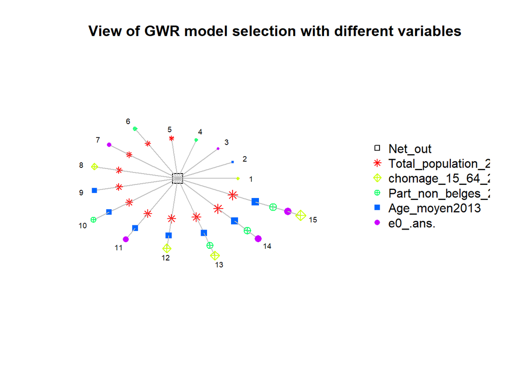

```r
sorted.models <- model.sort.gwr(model.sel, numVars = length(IndVars1),
ruler.vector = model.sel[[2]][,2])
model.list <- sorted.models[[1]]
#X11(width = 12, height = 6)
model.view.gwr(DepVar, IndVars1, model.list = model.list)
```

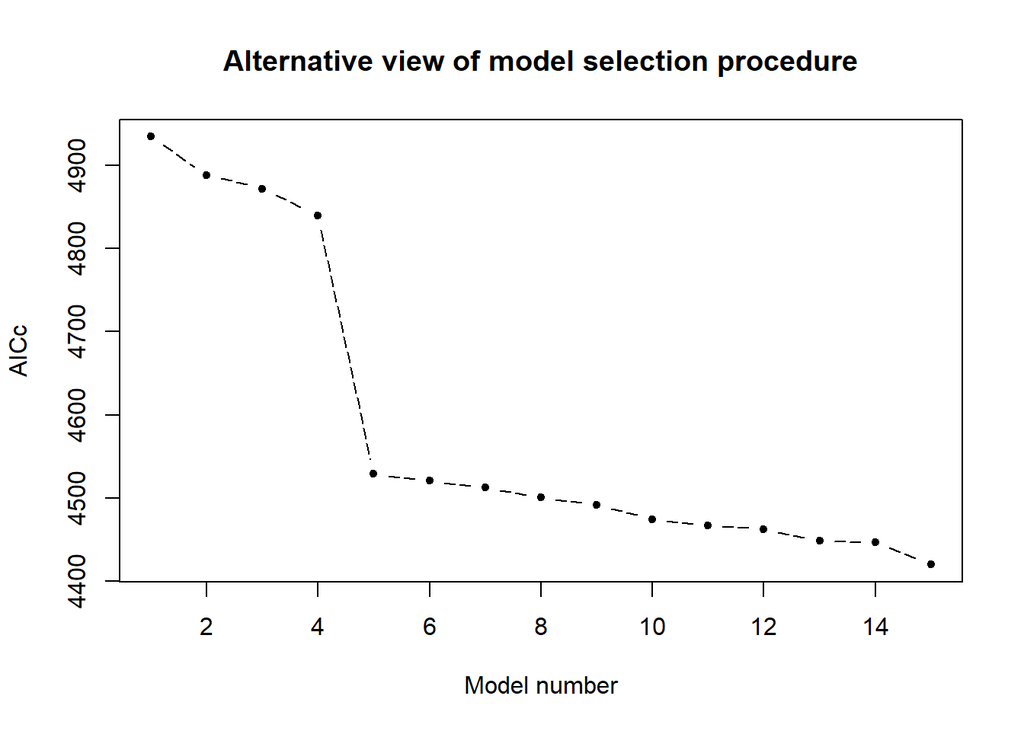

```r
plot(sorted.models[[2]][,2], col = "black", pch = 20, lty = 5,
main = "Alternative view of model selection procedure",
ylab = "AICc", xlab = "Model number", type = "b")
```

According to the above figures, we should choose model 15 because it has the lowest AICc. We begin by determining the best bandwidth and then match the basic local model:

## 4.2 Spatial Heterogeneity (Geographically Weighted Regression (GWR))

```r
bw.a <- bw.gwr(Net_out~Wa_sp_01$Total_population_2013 +
    Wa_sp_01$Age_moyen2013 + Wa_sp_01$Age_moyen2013 + Wa_sp_01$Part_non_belges_2013 +
    Wa_sp_01$e0_.ans.,
               data=Wa_sp_01, approach = "AICc",
                kernel = "bisquare", adaptive = TRUE)
```

```
## Adaptive bandwidth (number of nearest neighbours): 169 AICc value: 4682.205
## Adaptive bandwidth (number of nearest neighbours): 112 AICc value: 4675.534
## Adaptive bandwidth (number of nearest neighbours): 76 AICc value: 4671.603
## Adaptive bandwidth (number of nearest neighbours): 54 AICc value: 4687.271
## Adaptive bandwidth (number of nearest neighbours): 89 AICc value: 4671.764
## Adaptive bandwidth (number of nearest neighbours): 67 AICc value: 4675.811
## Adaptive bandwidth (number of nearest neighbours): 80 AICc value: 4670.351
## Adaptive bandwidth (number of nearest neighbours): 84 AICc value: 4670.51
## Adaptive bandwidth (number of nearest neighbours): 78 AICc value: 4670.983
## Adaptive bandwidth (number of nearest neighbours): 81 AICc value: 4669.982
## Adaptive bandwidth (number of nearest neighbours): 82 AICc value: 4669.631
## Adaptive bandwidth (number of nearest neighbours): 82 AICc value: 4669.631
```

```r
bw.a
```

```
## [1] 82
```

```r
gwr.res <- gwr.basic(Net_out~Total_population_2013+Age_moyen2013+Part_non_belges_2013+e0_.ans.+chomage_15_64_2013,
                    data=Wa_sp_01,bw=bw.a,kernel = "bisquare", adaptive = TRUE)
print(gwr.res)
```

```
##    *                       Package   GWmodel                             *
##    Program starts at: 2022-07-01 00:10:51
##    Call:
##    gwr.basic(formula = Net_out ~ Total_population_2013 + Age_moyen2013 +
##     Part_non_belges_2013 + e0_.ans. + chomage_15_64_2013, data = Wa_sp_01,
##     bw = bw.a, kernel = "bisquare", adaptive = TRUE)
##
##    Dependent (y) variable:  Net_out
##    Independent variables:  Total_population_2013 Age_moyen2013 Part_non_belges_2013 e0_.ans. chomage_15_64_2013
##    Number of data points: 262
##    *                    Results of Global Regression                     *
##
##    Call:
##     lm(formula = formula, data = data)
##
##    Residuals:
##     Min      1Q  Median      3Q     Max
## -8600.8  -910.3  -224.2   977.6  6551.6
##
##    Coefficients:
##                            Estimate Std. Error t value Pr(>|t|)
##    (Intercept)            6.718e+03  8.462e+03   0.794   0.4280
##    Total_population_2013 -1.122e-01  6.134e-03 -18.299   <2e-16 ***
##    Age_moyen2013          1.494e+02  7.859e+01   1.901   0.0584 .
##    Part_non_belges_2013   5.682e+01  2.251e+01   2.524   0.0122 *
##    e0_.ans.              -1.400e+02  9.572e+01  -1.463   0.1448
##    chomage_15_64_2013     1.723e+01  2.666e+01   0.646   0.5187
##
##    ---Significance stars
##    Signif. codes:  0 '***' 0.001 '**' 0.01 '*' 0.05 '.' 0.1 ' ' 1
##    Residual standard error: 1936 on 256 degrees of freedom
##    Multiple R-squared: 0.5876
##    Adjusted R-squared: 0.5796
##    F-statistic: 72.96 on 5 and 256 DF,  p-value: < 2.2e-16
##    ***Extra Diagnostic information
##    Residual sum of squares: 959560025
##    Sigma(hat): 1921.097
##    AIC:  4717.298
##    AICc:  4717.739
##    BIC:  4519.255
```

[output cut: 20 more lines]

```
##    Part_non_belges_2013    306.5000
##    e0_.ans.                432.7361
##    chomage_15_64_2013      120.8410
##    ************************Diagnostic information*************************
##    Number of data points: 262
##    Effective number of parameters (2trace(S) - trace(S'S)): 54.78973
##    Effective degrees of freedom (n-2trace(S) + trace(S'S)): 207.2103
##    AICc (GWR book, Fotheringham, et al. 2002, p. 61, eq 2.33): 4685.144
##    AIC (GWR book, Fotheringham, et al. 2002,GWR p. 96, eq. 4.22): 4622.923
##    BIC (GWR book, Fotheringham, et al. 2002,GWR p. 61, eq. 2.34): 4554.886
##    Residual sum of squares: 600432087
##    R-square value:  0.7419679
##    Adjusted R-square value:  0.6734092
##
##    Program stops at: 2022-07-01 00:10:51
```

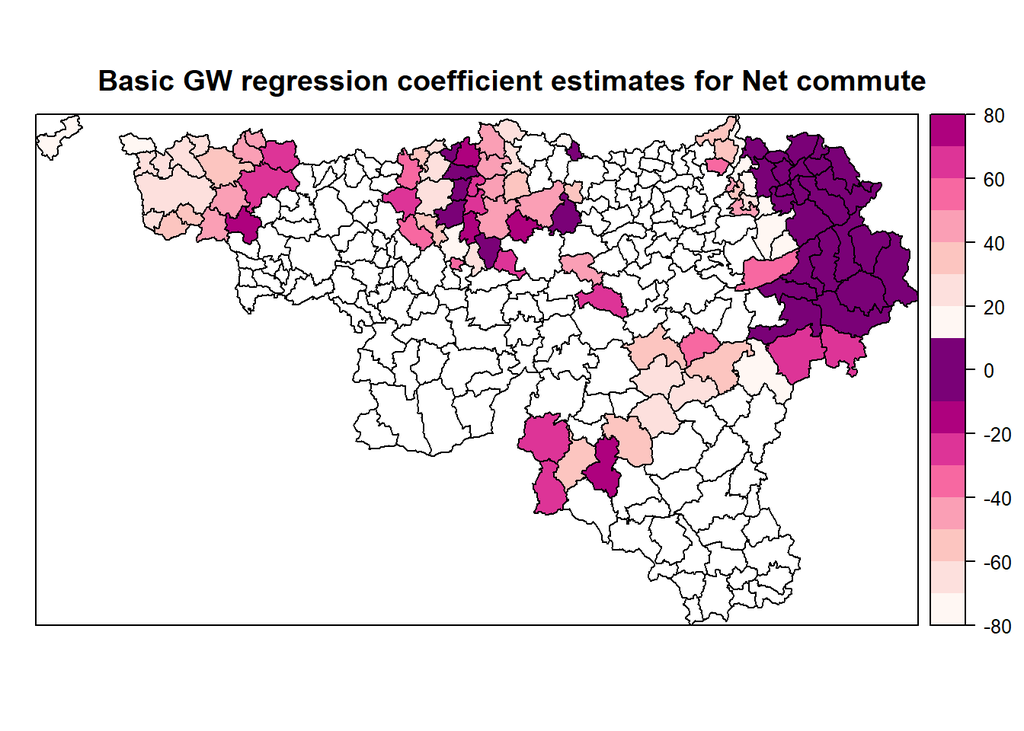

```r
mypalette <- brewer.pal(8, "RdPu")

spplot(gwr.res$SDF, "Part_non_belges_2013", key.space = "right", col.regions = mypalette,
      at = c(-80,-70,-60,-50,-40,-30,-20,-10,10,20,30,40,50,60,70,80),
      main = "Basic GW regression coefficient estimates for Net commute")
```